# No-Analogues in North American Pollen Space

## Abstract

*Most studies of novelty look for novelty relative to present day ecosystems, whether looking for novelty in the past or potential novelty in the future. But we are concerned about novelty during 21st century, where modern communities dis-aggregate, and we are challenged to understand which of these novel communities will be stable (equilibrial novelty) in the future, and which will remain in a state of transition (disequilibrial).*

*The general (Gleasonian) paradigm is that species respond individualistically to climate change, but in practice, those individualistic responses often result in the movement of entire communities across the landscape. At some time scales whole communities appear to move, while in others clear individualistic responses are visible. Under what conditions do we see new communities arise? When do communities persist?*

## Introduction

Estimates of dissimilarity and turnover in paleoecological records have been used to give us an indication of the novelty of ecosystems with respect to modern vegetation, or to provide information about how much change occurs through time within a record (Williams et al., 2001), often relating these changes to climate. The challenge in this case is that, as with modern ecosystems, changes in pollen composition at one location may represent points along a successional trajectory, where each time point represents significant compositional turnover, but, relative to the surrounding, heterogeneous landscape, very little change in forest composition occurs. Thus turnover as a single metric can provide results that are not uniquely tied to overall, landscape scale, changes in vegetation.

We can then imagine a set of scenarios, illustrated by plotting the various combinations of landscape and site level similarities.

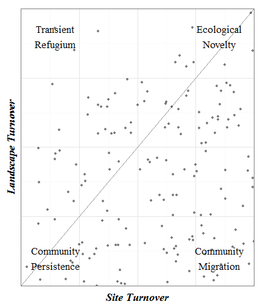

**Figure 1.** *Models for understanding turnover and dissimilarity in the pollen record. Community stability is represented by sites with low turnover relative to past assemblages at the site, and across the landscape. Community migration occurs when a site is highly siddimilar to past assemblages at the site, but has close analogues in the past landscape. Transient refugia occur when a site has low turnover, but becomes highly dissimilar from the past landscape. Ecological novelty occurs when a site is dissimilar from both the landscape and its own past assemblages.*

In the same way we can examine vegetation dissimilarity we can make use of transient climate models to use the same measures of dissimilarity for climate, here \( c_{m} \) (dissimilarity from modern), \( c_{s} \) (change at a site) and \( c_{l} \) (change relative to landscape).

**Table**. *Definitions for dissimilarity measures tested in this paper.*

[output not shown]

Turnover within a core just tells you how different vegetation at a single site is from one time period is to the next, however it may be deceptively high, in regions where there is high spatial heterogeneity, or large shifts between pioneer and climax vegetation associations it might be possible to see large shifts in turnover, but little regional change.

Landscape turnover has not been previously used as a metric of dissimilarity. It is a measure of how different an assemblage at one time period is to all pollen assemblages within a previous time period. In this sense, it is an estimate of how novel an ecosystem is with respect to all ecosystems that previously occupied the landscape. In a sense it is \( d_m \) turned on its head.

To assist in this endevour, we examine pollen records from the Neotoma Database, searching through the past, from the late-glacial to the modern to examine in which cases pollen assemblages appear to be non-analogue from the previous time period. The conceptual framework suggests that we were looking at landscape level turnover, not site turnover. While site-level turnover is a commonly used metric in paleoecological analysis, it is hampered by its sensitivity to stochastic effects. Large scale changes in vegetation at a single site might not reflect the kinds of broad scale community change we expect to see under conditions of future climate change. As such, comparing dissimilarity at a site to changes at a number of sites across the continent provides a better metric of landscape-scale dissimilarity.

[figure not shown]

**Figure 2**. *Turnover estimates for time t_i are measured as the minimum within site dissimilarity from the prior timestep (d_si) or the minimum dissimilarity from the landscape of pollen assemblages at the earlier timestep (d_li). In all cases the earlier timestep is defined as a time preiod between 250 and 750 years prior to the sample of interest. These two values then form a continuum of possibilities. High ds and low dl indicate disturbance events within a stable, heterogeneous landscape, high dl & high ds indicate broad-scale, rapid landscape turnover, high dl, low ds is relatively infrequent, but may indicate local refugia within a shifting landscape*

We expect that ecosystems will show patterns of change that can be explained through the multivariate use of these dissimilarity measures. For example, rapid species migration during the late-Pleistocene/eraly-Holocene transition should be apparent as high local turnover partnered with relatively low landscape change if entire communities are migrating northward. Strongly individualistic species responses would be visible as paired high site and landscape turnovers. Modern successional changes should be visible as sets of high self, low landscape changes. Low landscape and low self changes should be static ecosystems.

## Methods

We compile records of pollen from depositional records in the Neotoma Database. To assess whether pollen assemblages are 'non-analogue' we estimate squared-chord distance from pollen samples to a reference set that includes (1) all samples in the Neotoma Database that are between 250 and 750 calibrated years older than the sample, and (2) includes samples from the reference site.

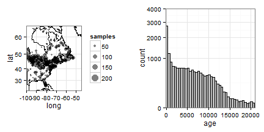

**Figure 2**. *Sample plot locations and bin sizes for each age class*.

To determine dissimilarity ofver time we estimate dissimilarity from the data using a bootstrap approach for which a sample is compared against a 'landscape' of sites that are between 250 and 750 years older than the sample in question. For any sample we first test whether a sample fom the site exists between 250 - 750 prior to the sample of interest. This will prevent anomalously high analogue distances for sites that have never previously been sampled, particularly when they represent new ecoregions. For each acceptable site we sample one assemblage from each site with samples in the previous 250 - 750 years. This produces a single sample from each site in the previous time window from which we estimate the minimum suqared chord dissimilarity. Since some sites have multiple samples in each 500 year time window we re-sample (with replacement) 100 times for each focal site, producing a sample of 100 minimum (squared-chord) dissimilarity values for each pollen assemblage at each site, for which there is a prior sample.

## Results

### Self and Landscape Dissimilarity:

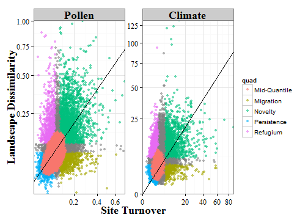

[output not shown]

**Figure X**. *Turnover and dissimilarity for individual sites from the Neotoma database for both climate and vegetation, showing a relationship between the two variables, but also considerable noise.*

Turnover within the core (change within the core from one time period to another) is correlated to landscape dissimilarity (\( r_{s} \) = 0.213, p < 0.001), but shows a great deal of variability around the 1:1 line (Figure X). The same plot, for climate in this case, shows a similar pattern (\( r_{s} \) = 0.2, p < 0.001), although the scale of dissimilarity values is much higher for the climate data due to the difference in base units for the two measures (percentages vs. scaled climate values). The central region of dissimilarity is generally shifted toward the regions we identify as 'Persistence', indicating that throughout the late-Glacial and Holocene (in particular) low turnover at both the site and landscape level was the rule.

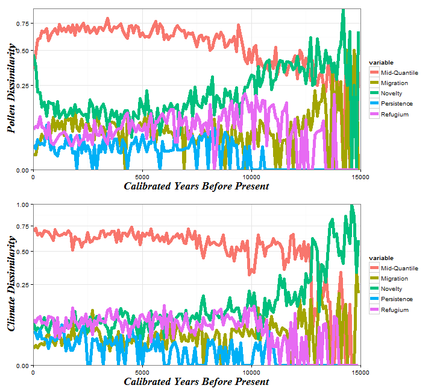

**Figure X**. *Proportion of sites within each time window showing turnover rates representing novelty, mighration, persistence or refugium.*

When we examine the relative proportions of sites that appear to show migration, novelty, persistence and refugium we see that both climate and vegetation turnover are fairly well correlated (\( r_{mantel} \) = 0.693, p = 0.001), but differences between the records are clear (Figure X).

Constrained clustering (using `chclust` in `rioja`) shows five main groupings the pollen and climate data, however, cut points differ between the two. The earliest Pollen Zone, P1, occurs only from 14500 - 15000 cal. yr BP, where Novelty represents the dominant class, with a smaller component of Migration and few sites with Mid-Quantile turnover levels. Pollen zone P2 extends from 12100 - 14400 cal yr BP, with Novelty again dominant, but declining as the Mid-Quantile class increases, indicating progressively lower landscape and site level changes. Increases in the Refugium class may occur as site level change slows in more southern regions relative to higher landscape level turnover across the domain.

Pollen Zone 3, from 9700 - 12000 continues the pattern of overall declining turnover rates, as evidenced by the increase in Mid-Quantile points. At this point the Refugium class reaches its maximum (20% of all records) and the Persistence class, sites with very low landscape and site level turnover begin to appear in the record. This is evidence for a slowing of ecological reorganization across eastern North America, supported by other paleoecological studies.

Pollen Zone 5 represents the post-EuroAmerican Settlement era. Here we see a rapid rise in Novelty as communities re-organize, and as disturbance-related taxa such as Ambrosia are released. This rapid increase in Novelty is not seen in studies such as Shuman since the baseline for these studies is the modern era, and as such they are unable to capture the rapid increase in Novelty. It is shocking to see that the increase in Novelty (to 50% in the last time bin) is at last as high as turnover following deglaciation 12000 - 14000 cal yr. BP, during the 'Non-Analogue' era in the southern Great Lakes Region (sensu Gill et al.). This indicates that the extent of anthropogenic change in modern ecological communities in North America is much higher than we might have expected, and, given the length of time over which communities continued to re-organize following rapid climate turnover in the paleo record, this re-organization may persist for much longer than anticipated.

Climate data can be divided into five zones as well. These zones do not correspond well to the pollen data, in part due to higher variability for some of the dissimilarity classes (Fig X), but also because of different overall patterns, in particular, patterns of Novelty. Zone C1 (15000 - 13600 cal yr BP) maintains high Novelty values, but ends rapidly as Novelty declines and then recovers during Zone C2 (13500 - 12800 cal yr BP). Zone C2 is a short lived period with highly variable Novelty and Mid-Quantile values, as well as higher values for the Migration class, indicating climate was changing systematically in places across the region, perhaps in response to regional scale warming. Zone C3 (12800 - 11300 cal yr BP) shows another decline in Novelty, largely in response to a rapid increase in Mid-Quantile values, indicating a stabilization of regional climate change over that period. A spike in Novelty at the end of Zone C3 is associated with a decline in Migration, Mid-Quantile and Refugium classes, likely associated with rapid Younger Dryas cooling.

Zone C4 (11300 - 6000 cal yr BP) is the first zone where Persistence becomes a feature of the dissimilarity space, indicating broader regions where climate changes little over time are appearing on the landscape. At the same time Novelty has declined rapidly, and continues to decline to 6000 cal yr BP, while the Refugium class increases initially, and then remains relatively stable until the present, although values remain low, between 8 - 10%. The final zone (Zone C5) continues the pattern of C4, maintaining relative stability for each of the turnover classes. Migration classes hit short lived maxima at 1800 and 2700 cal yr BP. The high for Migration at 1800 cal yr BP is also a high for Refugium and a local maxima for Novelty, indicating the potential for a regional-scale climatic event at this time.

## Discussion

Turnover or analogues? When we are looking at non-analogues it turns out that it's really the modern.